# NosAnalizamos

# 5 Tabla de estadisticos

Obtén una tabla de estadisticos de estas variables, donde en la primera columna aparezca cada asignatura y las siguientes columnas se correspondan con: valor minimo, percentil 25, mediana, valor medio, desviacion tipica, percentil 75, valor maximo. Resultados con 2 decimales.

```r
stats_table <- tabla_estadisticos(datos, asignaturas)
knitr::kable(stats_table)
```

| asignatura | min | p25 | mediana | media | sd | p75 | max |
| --- | --- | --- | --- | --- | --- | --- | --- |
| ALG | 1.9 | 6.00 | 6.72 | 6.41 | 1.65 | 7.50 | 10.00 |
| ANM | 3.4 | 6.97 | 7.90 | 7.61 | 1.45 | 8.50 | 9.81 |
| FP | 3.0 | 3.53 | 6.00 | 5.77 | 2.25 | 7.25 | 9.50 |
| DCS | 3.0 | 6.79 | 7.65 | 7.42 | 1.36 | 8.30 | 9.80 |
| MD | 1.5 | 5.47 | 6.40 | 6.12 | 1.99 | 7.41 | 9.50 |

# 6 ggpairs: relaciones entre variables

Usa `ggpairs` de la libreria `GGally` y representa las relaciones entre las calificaciones.

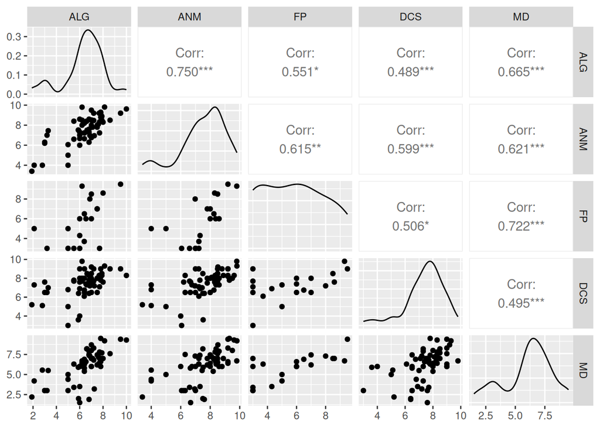

```r
GGally::ggpairs(datos %>% select(all_of(asignaturas)))
```

# 7 Matrices de correlacion y covarianza

Determina las matrices de correlacion y covarianza de las calificaciones con las opciones “Spearman” y “Pearson”, e indica que pares de variables tienen la correlacion mas alta.

```r
datos_notas <- datos %>% select(all_of(asignaturas))

cor_pearson <- cor(datos_notas, method = "pearson", use = "pairwise.complete.obs")
cor_spearman <- cor(datos_notas, method = "spearman", use = "pairwise.complete.obs")
cov_matrix <- cov(datos_notas, use = "pairwise.complete.obs")

max_pearson <- max_correlaciones(cor_pearson)
max_spearman <- max_correlaciones(cor_spearman)

cor_pearson
```

```
##           ALG       ANM        FP       DCS        MD
## ALG 1.0000000 0.7496902 0.5506998 0.4892651 0.6654584
## ANM 0.7496902 1.0000000 0.6146760 0.5991354 0.6214427
## FP  0.5506998 0.6146760 1.0000000 0.5057321 0.7220793
## DCS 0.4892651 0.5991354 0.5057321 1.0000000 0.4954562
## MD  0.6654584 0.6214427 0.7220793 0.4954562 1.0000000
```

```r
cor_spearman
```

```
##           ALG       ANM        FP       DCS        MD
## ALG 1.0000000 0.6800374 0.6183589 0.5609870 0.7225803
## ANM 0.6800374 1.0000000 0.6997607 0.6457497 0.6790033
## FP  0.6183589 0.6997607 1.0000000 0.4577758 0.7283962
## DCS 0.5609870 0.6457497 0.4577758 1.0000000 0.5952220
## MD  0.7225803 0.6790033 0.7283962 0.5952220 1.0000000
```

```r
cov_matrix
```

```
##          ALG      ANM       FP      DCS       MD
## ALG 2.729793 1.796924 2.030932 1.102668 2.183312
## ANM 1.796924 2.104582 1.886942 1.185615 1.790252
## FP  2.030932 1.886942 5.080105 1.697395 2.773605
## DCS 1.102668 1.185615 1.697395 1.860680 1.342058
## MD  2.183312 1.790252 2.773605 1.342058 3.943302
```

```r
max_pearson
```

```
## # A tibble: 1 × 3
##   var1  var2  correlacion
##   <chr> <chr>       <dbl>
## 1 ALG   ANM         0.750
```

```r
max_spearman
```

```
## # A tibble: 1 × 3
##   var1  var2  correlacion
##   <chr> <chr>       <dbl>
## 1 FP    MD          0.728
```

# 8 Boxplots de calificaciones

Representa en una misma grafica los boxplots con las calificaciones obtenidas en las diferentes asignaturas.

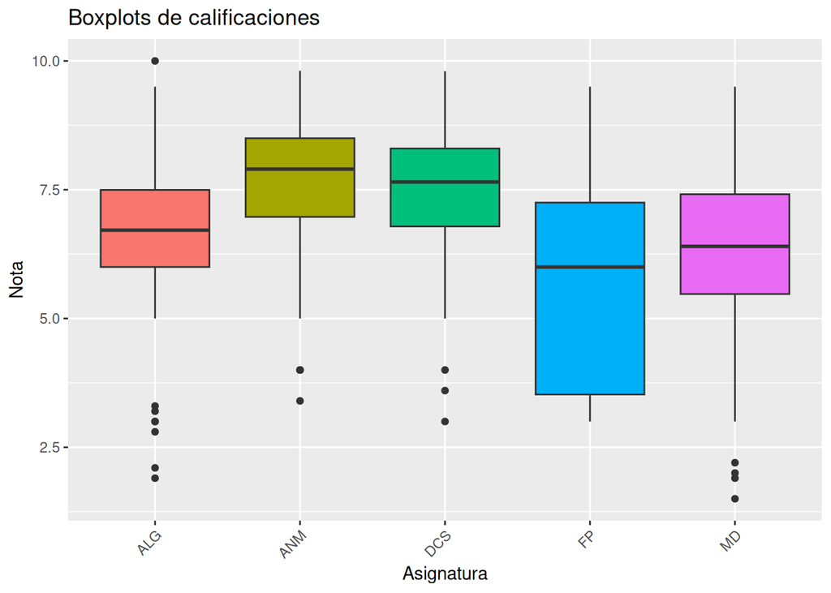

```r
notas_long <- datos %>%
  select(all_of(asignaturas)) %>%
  pivot_longer(cols = everything(), names_to = "asignatura", values_to = "nota")

ggplot(notas_long, aes(x = asignatura, y = nota, fill = asignatura)) +
  geom_boxplot() +
  theme(legend.position = "none", axis.text.x = element_text(angle = 45, hjust = 1)) +
  labs(title = "Boxplots de calificaciones", x = "Asignatura", y = "Nota")
```

# 9 Boxplots por sexo

Anade la variable sexo al conjunto de datos y realiza la representacion del boxplot de calificaciones por asignatura coloreando segun dicha variable.

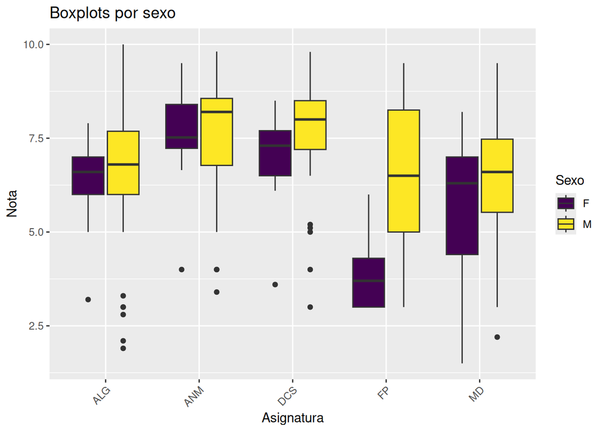

```r
datos <- datos %>% mutate(sexo = Sex)

notas_sexo_long <- datos %>%
  select(sexo, all_of(asignaturas)) %>%
  pivot_longer(cols = all_of(asignaturas), names_to = "asignatura", values_to = "nota")

ggplot(notas_sexo_long, aes(x = asignatura, y = nota, fill = sexo)) +
  geom_boxplot() +
  theme(axis.text.x = element_text(angle = 45, hjust = 1)) +
  labs(title = "Boxplots por sexo", x = "Asignatura", y = "Nota", fill = "Sexo")
```

# 10 Alumnos con calificaciones en todas las asignaturas

Selecciona los alumnos que tengan calificaciones en todas las asignaturas y representalas graficamente. En el eje X aparece el usuario (girado 90 grados) y en el eje Y la calificacion numerica con un color distinto para cada asignatura. Se muestra un diagrama de lineas y un punto por asignatura y alumno.

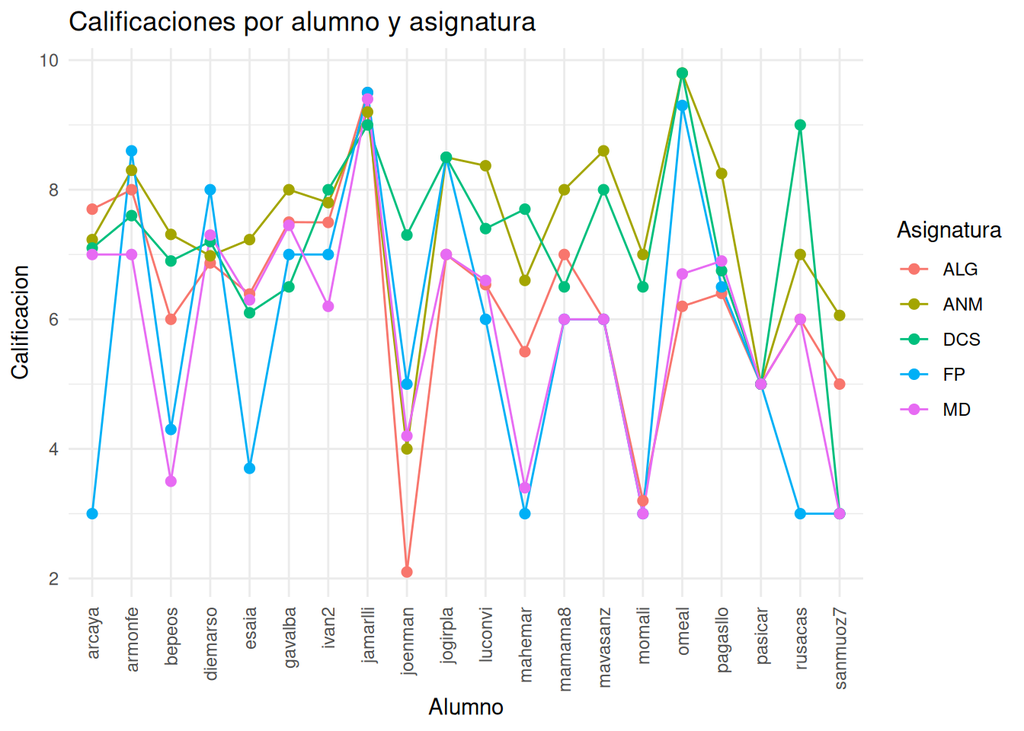

```r
datos_completos <- datos %>%
  filter(if_all(all_of(asignaturas), ~ !is.na(.x))) %>%
  select(Id, all_of(asignaturas))

datos_long <- datos_completos %>%
  pivot_longer(cols = -Id, names_to = "asignatura", values_to = "nota")

ggplot(datos_long, aes(x = Id, y = nota, color = asignatura, group = asignatura)) +
  geom_line() +
  geom_point(size = 2) +
  theme_minimal() +
  theme(axis.text.x = element_text(angle = 90, hjust = 1, vjust = 0.5)) +
  labs(
    title = "Calificaciones por alumno y asignatura",
    x = "Alumno",
    y = "Calificacion",
    color = "Asignatura"
  )
```

# 11 Comparacion 2022 vs 2026

Sin modificar el codigo, se usa el fichero de 2026 y se comparan los resultados con 2022.

```r
path_2026 <- "data/NosAutoanalizamos2026 - NosAutoanalizamos (1).tsv"
datos_2026 <- preparar_datos(path_2026, asignaturas)
stats_2026 <- tabla_estadisticos(datos_2026, asignaturas)
stats_2026
```

```
## # A tibble: 5 × 8
##   asignatura   min   p25 mediana media    sd   p75   max
##   <chr>      <dbl> <dbl>   <dbl> <dbl> <dbl> <dbl> <dbl>
## 1 ALG         0.28  3       6.55  5.45  2.36  7.47   8.8
## 2 ANM         0.08  5.01    6.6   6.12  2.07  7.55  10
## 3 FP          0.8   3       3     4.4   2.39  7      8.6
## 4 DCS         3     4       7.1   6.11  2.18  8      9
## 5 MD          2.6   5.58    6.45  6.12  1.68  7.43   8.3
```

```r
comparacion_medias <- tibble(
  asignatura = asignaturas,
  media_2022 = sapply(datos[asignaturas], mean, na.rm = TRUE),
  media_2026 = sapply(datos_2026[asignaturas], mean, na.rm = TRUE)
) %>%
  mutate(diferencia = round(media_2026 - media_2022, 2))

knitr::kable(comparacion_medias)
```

| asignatura | media_2022 | media_2026 | diferencia |
| --- | --- | --- | --- |
| ALG | 6.406000 | 5.454259 | -0.95 |
| ANM | 7.606500 | 6.121600 | -1.48 |
| FP | 5.770000 | 4.400000 | -1.37 |
| DCS | 7.421000 | 6.107407 | -1.31 |
| MD | 6.118333 | 6.125000 | 0.01 |

# 12 Preguntas con datos 2026

Responde a las preguntas usando datos 2026. Se corrigen valores invalidos: si no son M o F en `Sex`, o no son Derecha/Izquierda en `NW.Hnd`, se reemplazan por `NA`. Lo mismo para `Smoke`.

```r
fecha_referencia <- ymd("2026-02-01")
datos_2026 <- datos_2026 %>%
  mutate(Edad_a_01_02_2026 = as.numeric(difftime(fecha_referencia, FechaNac, units = "days")) / 365.25)
```

## 12.1 Alumno mas joven a 01/02/2026

```r
edad_mas_joven <- min(datos_2026$Edad_a_01_02_2026, na.rm = TRUE)
round(edad_mas_joven, 2)
```

```
## [1] 18.12
```

## 12.2 Alumnos que simultanean trabajo y estudios

```r
alumnos_trabajo_estudios <- datos_2026 %>%
  filter(!is.na(Hwork) & Hwork > 0) %>%
  nrow()
alumnos_trabajo_estudios
```

```
## [1] 14
```

## 12.3 Fumadores por sexo

```r
datos_fumadores <- datos_2026 %>%
  filter(Smoke == "Si") %>%
  count(Sex, name = "num_fumadores")
datos_fumadores
```

```
## # A tibble: 1 × 2
##   Sex   num_fumadores
##   <ord>         <int>
## 1 M                 7
```

## 12.4 Media y varianza de Wr.Hnd segun sexo

```r
datos_wr_hnd <- datos_2026 %>%
  group_by(Sex) %>%
  summarise(
    media_wr_hnd = mean(Wr.Hnd, na.rm = TRUE),
    varianza_wr_hnd = var(Wr.Hnd, na.rm = TRUE)
  )
knitr::kable(datos_wr_hnd)
```

| Sex | media_wr_hnd | varianza_wr_hnd |
| --- | --- | --- |
| F | 18.04348 | 3.717115 |
| M | 19.98824 | 1.732585 |

## 12.5 Relacion entre sexo y mano con la que se escribe (NW.Hnd)

```r
tabla_sexo_mano <- table(datos_2026$Sex, datos_2026$NW.Hnd, useNA = "no")
tabla_sexo_mano
```

```
##
##     Derecha Izquierda
##   F      22         2
##   M      29         7
```

```r
chisq_test <- chisq.test(tabla_sexo_mano, correct = FALSE)
chisq_test$p.value
```

```
## [1] 0.2376743
```

## 12.6 Relacion lineal entre Height y Wr.Hnd

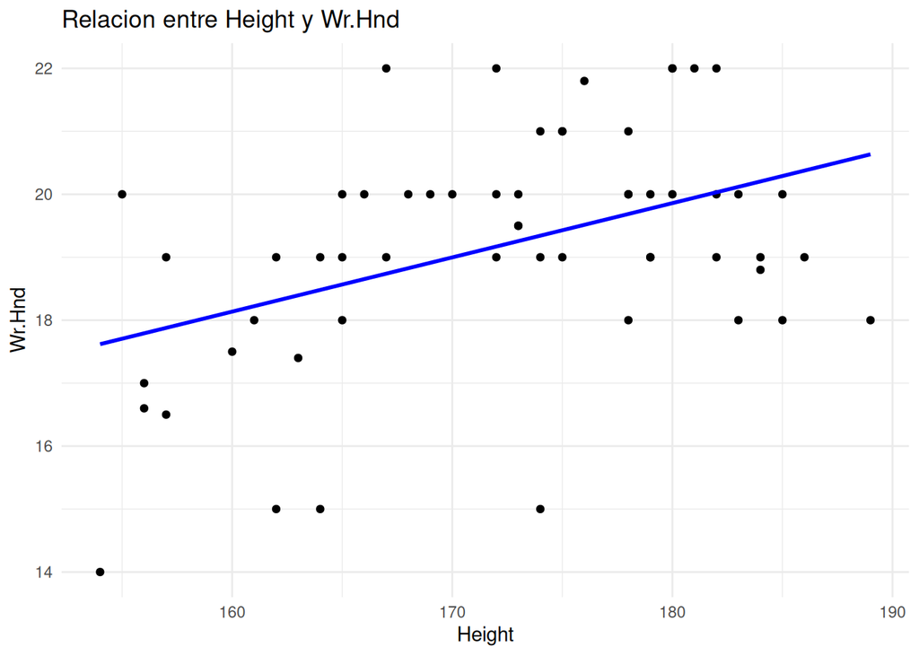

```r
ggplot(datos_2026, aes(x = Height, y = Wr.Hnd)) +
  geom_point() +
  geom_smooth(method = "lm", se = FALSE, color = "blue") +
  labs(title = "Relacion entre Height y Wr.Hnd", x = "Height", y = "Wr.Hnd") +
  theme_minimal()
```

```r
cor_pearson_height_wr_hnd <- cor(datos_2026$Height, datos_2026$Wr.Hnd, method = "pearson", use = "complete.obs")
cor_spearman_height_wr_hnd <- cor(datos_2026$Height, datos_2026$Wr.Hnd, method = "spearman", use = "complete.obs")
cor_pearson_height_wr_hnd
```

```
## [1] 0.4310869
```

```r
cor_spearman_height_wr_hnd
```

```
## [1] 0.3347821
```

## 12.7 Outliers en altura (identificador de Hampel)

```r
madm <- function(x, na.rm = TRUE) {
  med <- median(x, na.rm = na.rm)
  1.4826 * median(abs(x - med), na.rm = na.rm)
}

regla_hampel <- function(x) {
  med <- median(x, na.rm = TRUE)
  m <- madm(x, na.rm = TRUE)
  x < (med - 3 * m) | x > (med + 3 * m)
}

datos_2026 <- datos_2026 %>%
  mutate(outlier_height = regla_hampel(Height))

outliers_height <- datos_2026 %>%
  filter(outlier_height) %>%
  select(Id, Height)

outliers_height
```

```
## # A tibble: 0 × 2
## # ℹ 2 variables: Id <chr>, Height <dbl>
```

## 12.8 Imputacion generalizada de FP con la media

```r
media_fp <- mean(datos_2026$FP, na.rm = TRUE)
media_fp
```

```
## [1] 4.4
```

## 12.9 Imputacion de FP segun PulseCat

```r
datos_2026 <- datos_2026 %>%
  mutate(PulseCat = ifelse(Pulse >= 65, "PulseH", "PulseL"))

media_fp_pulse <- datos_2026 %>%
  group_by(PulseCat) %>%
  summarise(media_fp = mean(FP, na.rm = TRUE))

media_fp_pulse
```

```
## # A tibble: 3 × 2
##   PulseCat media_fp
##   <chr>       <dbl>
## 1 PulseH       5.1
## 2 PulseL       4.14
## 3 <NA>         3
```

## 12.10 Relacion entre Pulse y calificaciones en ALG

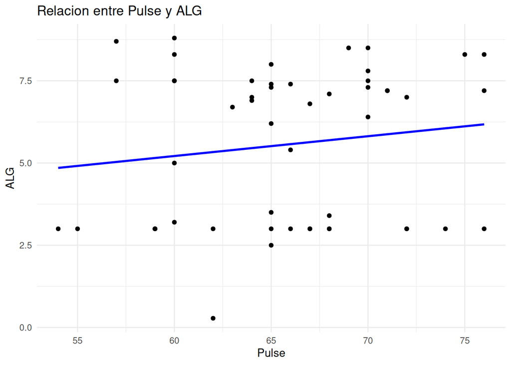

```r
ggplot(datos_2026, aes(x = Pulse, y = ALG)) +
  geom_point() +
  geom_smooth(method = "lm", se = FALSE, color = "blue") +
  labs(title = "Relacion entre Pulse y ALG", x = "Pulse", y = "ALG") +
  theme_minimal()
```

```r
cor_pearson_pulse_alg <- cor(datos_2026$Pulse, datos_2026$ALG, method = "pearson", use = "complete.obs")
cor_spearman_pulse_alg <- cor(datos_2026$Pulse, datos_2026$ALG, method = "spearman", use = "complete.obs")
cor_pearson_pulse_alg
```

```
## [1] 0.1419435
```

```r
cor_spearman_pulse_alg
```

```
## [1] 0.08321638
```